# P2_Analyse-systemes-educatifs-e2

Auteur·rice

Affiliation

Guillaume LAFON

OpenClassrooms

Date de publication

20 décembre 2024

Résumé

**But de la mission** : déterminer si les données sur l’éducation de la banque mondiale peut informer les décisions d’ouverture vers de nouveaux pays

**Détails de la mission** :

1. Quels sont les pays avec un fort potentiel de clients pour nos services ?
2. Pour chacun de ces pays, quelle sera l’évolution de ce potentiel de clients ?
3. Dans quels pays l’entreprise doit-elle opérer en priorité ?

Les données de la Banque mondiale sont disponibles à l’adresse suivante : https://datacatalog.worldbank.org/dataset/education-statistics. L’organisme “EdStats All Indicator Query” de la Banque mondiale répertorie 4000 indicateurs internationaux décrivant l’accès à l’éducation, l’obtention de diplômes et des informations relatives aux professeurs, aux dépenses liées à l’éducation… Plus d’info sur ce site : http://datatopics.worldbank.org/education/.

Mots clés

EdStats, OpenClassrooms, academy

## 1 Introduction

### 1.1 Contexte

Academy, start-up EdTech, propose des formations en ligne pour des publics de niveau lycée et université. Dans le cadre d’une expansion internationale, l’entreprise explore les opportunités sur de nouveaux marchés grâce à des données globales sur l’éducation issues de la Banque mondiale (EdStats All Indicator Query), qui regroupent plus de 4000 indicateurs relatifs à l’accès à l’éducation, les dépenses, et les résultats académiques.

### 1.2 Objectif

Cette analyse exploratoire a pour but de :

1. Évaluer la qualité et la pertinence des données pour le projet d’expansion.
   1. Valider la qualité du jeu de données (valeurs manquantes ? doublons ?)
   2. Pour chaque fichiers décrire leurs contenues
   3. Bilan de l’analyse
2. Identifier des zones géographiques stratégiques présentant un fort potentiel éducatif et économique.
   1. Filtrer les données
   2. Définir une liste de pays
3. Dégager des indicateurs clés pour orienter les futures décisions d’investissement.
   1. Quelle tranche de population ?
   2. Quelles années conserver ?
4. Présenter les résultats
   1. Calculer des indicateurs
   2. Analyse graphique

## 2 Découverte des données

### 2.1 Importation des librairies et chargement des fichiers csv

```python
from pathlib import Path

import pandas as pd

from IPython.display import Markdown
from itables import show
import itables.options as opt
import missingno as msno
import plotly.express as px

# Afficher ecriture scientifique des valeurs numériques
pd.set_option("display.float_format", "{:g}".format)


opt.scrollY = "200px"
opt.scrollCollapse = True
opt.paging = False
opt.column_filters = "header"


dataset_folder = Path("data/Dataset_Edstats_csv/")
csv_files = list(dataset_folder.glob("*.csv"))
print(f"Fichiers CSV trouvés : {[file.name for file in csv_files]}")
```

```
Fichiers CSV trouvés : ['EdStatsCountry.csv', 'EdStatsCountry-Series.csv', 'EdStatsData.csv', 'EdStatsSeries.csv', 'EdStatsFootNote.csv']
```

### 2.2 Première lecture et description des fichiers csv

```python
dfs = {file.stem: pd.read_csv(file) for file in csv_files}
```

#### 2.2.1 Affichage des 50 premières lignes des fichiers

**EdStatsCountry**

Country Code

Short Name

Table Name

Long Name

2-alpha code

Currency Unit

Special Notes

Region

Income Group

WB-2 code

National accounts base year

National accounts reference year

SNA price valuation

Lending category

Other groups

System of National Accounts

Alternative conversion factor

PPP survey year

Balance of Payments Manual in use

External debt Reporting status

System of trade

Government Accounting concept

IMF data dissemination standard

Latest population census

Latest household survey

Source of most recent Income and expenditure data

Vital registration complete

Latest agricultural census

Latest industrial data

Latest trade data

Latest water withdrawal data

Unnamed: 31

[figure not shown]

Loading ITables v2.2.4 from the internet... (need [help](https://mwouts.github.io/itables/troubleshooting.html)?)

**EdStatsCountry-Series**

CountryCode

SeriesCode

DESCRIPTION

Unnamed: 3

[figure not shown]

Loading ITables v2.2.4 from the internet... (need [help](https://mwouts.github.io/itables/troubleshooting.html)?)

**EdStatsData**

Country Name

Country Code

Indicator Name

Indicator Code

1970

1971

1972

1973

1974

1975

1976

1977

1978

1979

1980

1981

1982

1983

1984

1985

1986

1987

1988

1989

1990

1991

1992

1993

1994

1995

1996

1997

1998

1999

2000

2001

2002

2003

2004

2005

2006

2007

2008

2009

2010

2011

2012

2013

2014

2015

2016

2017

2020

2025

2030

2035

2040

2045

2050

2055

2060

2065

2070

2075

2080

2085

2090

2095

2100

Unnamed: 69

[figure not shown]

Loading ITables v2.2.4 from the internet... (need [help](https://mwouts.github.io/itables/troubleshooting.html)?)

**EdStatsSeries**

Series Code

Topic

Indicator Name

Short definition

Long definition

Unit of measure

Periodicity

Base Period

Other notes

Aggregation method

Limitations and exceptions

Notes from original source

General comments

Source

Statistical concept and methodology

Development relevance

Related source links

Other web links

Related indicators

License Type

Unnamed: 20

[figure not shown]

Loading ITables v2.2.4 from the internet... (need [help](https://mwouts.github.io/itables/troubleshooting.html)?)

**EdStatsFootNote**

CountryCode

SeriesCode

Year

DESCRIPTION

Unnamed: 4

[figure not shown]

Loading ITables v2.2.4 from the internet... (need [help](https://mwouts.github.io/itables/troubleshooting.html)?)

#### 2.2.2 Affichage des types utilisés pour chaque fichiers

Conversion des types pour chaque dataframe. Permet d’optimiser les ressources réduire la zone mémoire utilisé.

```python
def convert_columns_types(df_data: pd.DataFrame) -> pd.DataFrame:
    df_data = df_data.convert_dtypes()
    fcols = df_data.select_dtypes("float").columns
    icols = df_data.select_dtypes("integer").columns

    df_data[fcols] = df_data[fcols].apply(pd.to_numeric, downcast="float")
    df_data[icols] = df_data[icols].apply(pd.to_numeric, downcast="integer")
    return df_data
```

```python
cols = ["Country Name", "Country Code","Indicator Name", "Indicator Code"]
dfs["EdStatsData"][cols] = dfs["EdStatsData"][cols].astype("category")
```

**EdStatsCountry**

None

0

[figure not shown]

Loading ITables v2.2.4 from the internet... (need [help](https://mwouts.github.io/itables/troubleshooting.html)?)

**EdStatsCountry-Series**

None

0

[figure not shown]

Loading ITables v2.2.4 from the internet... (need [help](https://mwouts.github.io/itables/troubleshooting.html)?)

**EdStatsData**

None

0

[figure not shown]

Loading ITables v2.2.4 from the internet... (need [help](https://mwouts.github.io/itables/troubleshooting.html)?)

**EdStatsSeries**

None

0

[figure not shown]

Loading ITables v2.2.4 from the internet... (need [help](https://mwouts.github.io/itables/troubleshooting.html)?)

**EdStatsFootNote**

None

0

[figure not shown]

Loading ITables v2.2.4 from the internet... (need [help](https://mwouts.github.io/itables/troubleshooting.html)?)

### 2.3 Affiche les infos détaillées de chaque dataframes et présente les données dans un tableau

```python
# Liste pour stocker les informations de chaque dataframe
summary_data = []
for name, df in dfs.items():
    summary_data.append({
        "Fichier": name,
        "Dimensions": df.shape,
        "Noms colonnes": df.columns.to_list(),
        "Types de données": df.dtypes.to_dict(),
    })

# Création d'un DataFrame pour afficher ces informations
summary_df = pd.DataFrame(summary_data)

# Affichage du tableau dans Jupyter Notebook
show(summary_df)
```

Fichier

Dimensions

Noms colonnes

Types de données

[figure not shown]

Loading ITables v2.2.4 from the internet... (need [help](https://mwouts.github.io/itables/troubleshooting.html)?)

### 2.4 Résumé du contenu des 5 fichiers csv

**Note**

- **EdStatsCountry-Series**, **EdStatsSeries**, **EdStatsFootNotes** contiennent des données relatives à la source des données.  
  Pour le moment ces fichiers ne sont pas pertinent pour mon analyse. Je pourrais y revenir en cas de besoin de précisions.
- **EdStatsCountry** contient des informations sur la géolocalisation des pays (dans quelle partie du monde ils se situent), informations sur la date du recensement de la population et la monnaie utilisée.  
  ➡️ Je vais conserver les colonne `["Country Code", "Short Name", "Currency Unit", "Region"]` Ces colonnes peuvent m’être utile pour grouper mes données
- **EdStatsData** est le fichier le plus pertinent pour mon analyse.
  - Collecte des données par rapport à 3665 critères de 242 pays.
  - Les données sont répertoriés par année de 1970 à 2100.

↪️ Pour la suite je vais maintenant analyser le fichier **EdStatsData** - Je commence par analyser la colonne `Country Code` il me semble qu’il y a trop de pays - Puis les indicateurs pour mon analyse (colonne `Indicator Name`). - Enfin je conserverai uniquement les colonnes des années qui contiennent le moins de données manquantes

## 3 Analyse EdStatsData

```python
edStatsData = dfs["EdStatsData"]
```

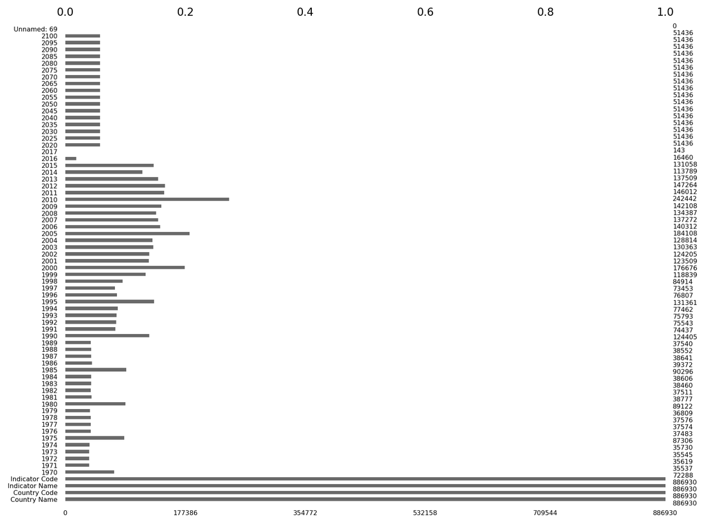

```python
msno.bar(
    edStatsData,
    figsize=(10, 8),
    fontsize=6,
)
```

On peut voir avec le graphique ci dessus qu’il y a beaucoup de valeurs manquantes. Voyons voir maintenant leurs répartitions:

```python
show(edStatsData.isnull().mean() *100)
```

None

0

[figure not shown]

Loading ITables v2.2.4 from the internet... (need [help](https://mwouts.github.io/itables/troubleshooting.html)?)

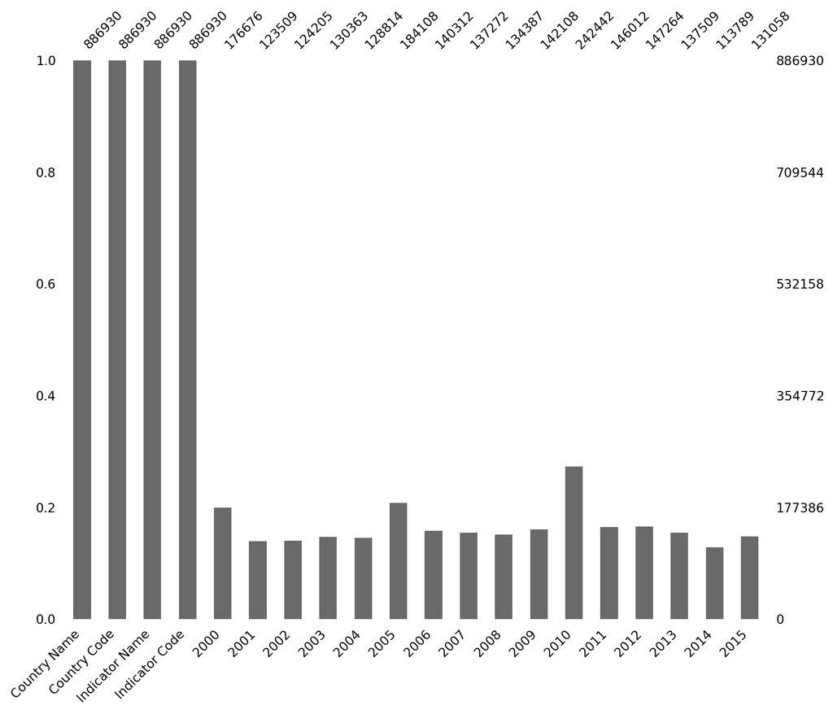

```python
# Suppression des colonnes non représentatives
edStatsData_filtered = edStatsData.drop(columns=edStatsData.loc[:, "1970":"1999"].columns)
edStatsData_filtered = edStatsData_filtered.drop(columns=edStatsData_filtered.loc[:, "2016":].columns)
msno.bar(
    edStatsData_filtered,
    figsize=(10, 8),
    fontsize=10,
)
```

### 3.1 Supprime toutes les lignes sans valeurs

On commence par vérifier s’il y a des lignes sans aucune valeurs

```python
# Sélectionner toutes les colonnes sauf les 3 premières qui contiennent Country Names, Country Codes et indicateurs
columns_to_check = edStatsData_filtered.loc[:, "2000":"2015"]
# Cherche les lignes sans vides
empty_rows_mask = columns_to_check.isna().all(axis=1)
# Afficher le nombre de lignes à supprimer, c'est-à-dire celles qui ont toutes les valeurs manquantes dans les colonnes de 2000 à 2015
num_empty_rows = edStatsData_filtered[empty_rows_mask].shape[0]
display(Markdown(f"Nombre de lignes vides à supprimer: **{num_empty_rows}**"))
```

Nombre de lignes vides à supprimer: **538817**

```python
# Supprimer ces lignes du DataFrame en utilisant le masque créé précédemment
display(Markdown(f"Nombre de lignes **avant** suppression des lignes vides: **{edStatsData_filtered.shape[0]}**"))

edStatsData_filtered = edStatsData_filtered.dropna(axis=0, how="all", subset=columns_to_check.columns)

display(Markdown(f"Nombre de lignes **après** suppression des lignes vides: **{edStatsData_filtered.shape[0]}**"))
```

Nombre de lignes **avant** suppression des lignes vides: **886930**

Nombre de lignes **après** suppression des lignes vides: **348113**

```python
ISO_3166 = pd.read_csv(
    "https://raw.githubusercontent.com/lukes/ISO-3166-Countries-with-Regional-Codes/refs/heads/master/all/all.csv",
    usecols=["name", "alpha-3"],
)
```

```python
Markdown(f"La liste officielle qui répertorie les codes pays du monde contient **{ISO_3166["alpha-3"].nunique()}** codes")
```

La liste officielle qui répertorie les codes pays du monde contient **249** codes

```python
nb_country_code = edStatsData_filtered["Country Code"].nunique()
Markdown(f"EdStatsData contient **{nb_country_code}** codes de pays")
```

EdStatsData contient **242** codes de pays

On conserve que les codes présent dans la liste ISO_3166

```python
# Créer un masque pour identifier les pays valides selon ISO_3166
valid_countries = edStatsData_filtered["Country Code"].isin(ISO_3166["alpha-3"])
```

```python
# Identifier et afficher les pays supprimés
removed_countries = edStatsData_filtered[~valid_countries]
removed_countries_list = pd.Series(removed_countries["Country Name"].unique(), name="Country Name")
show(removed_countries_list, "Liste des 'Pays' supprimés")
```

Liste des 'Pays' supprimés

Country Name

[figure not shown]

Loading ITables v2.2.4 from the internet... (need [help](https://mwouts.github.io/itables/troubleshooting.html)?)

```python
# Filtrer les données pour conserver uniquement les pays valides
edStatsData_filtered = edStatsData_filtered[valid_countries]
show(edStatsData_filtered.head(50))
```

None

Country Name

Country Code

Indicator Name

Indicator Code

2000

2001

2002

2003

2004

2005

2007

2008

2009

2010

2011

2012

2013

2014

2015

[figure not shown]

Loading ITables v2.2.4 from the internet... (need [help](https://mwouts.github.io/itables/troubleshooting.html)?)

```python
Markdown(f"Nombres de pays après filtrage d'après la liste alpha-3: **{edStatsData_filtered['Country Name'].nunique()}**")
```

Nombres de pays après filtrage d’après la liste alpha-3: **215**

### 3.2 Analyse des indicateurs présents dans la colonne `Indicator Name` du fichier `EdStatsData`

```python
# Nombre total d'indicateurs avant filtrage
total_indicators_before_filter = edStatsData["Indicator Name"].nunique()
Markdown(f" Nombre indicateurs avant filtre années et filtre lignes vides: **{total_indicators_before_filter}**")
```

Nombre indicateurs avant filtre années et filtre lignes vides: **3665**

```python
# Liste des noms d'indicateurs après filtrage
filtered_indicators = pd.Series(
    name="Indicator Name",
    data=edStatsData_filtered["Indicator Name"].unique(),
)
display(Markdown(f"Nombre d'indicateurs disponibles après filtrage: **{filtered_indicators.nunique()}**"))

# Calcul et affichage du nombre d'indicateurs supprimés
removed_indicators_count = total_indicators_before_filter - filtered_indicators.nunique()
display(Markdown(f"Le premier filtrage a supprimé : **{removed_indicators_count}** indicateurs"))
```

Nombre d’indicateurs disponibles après filtrage: **3635**

Le premier filtrage a supprimé : **30** indicateurs

```python
show(filtered_indicators, "EdStatsData après suppresion des lignes vides")
```

EdStatsData après suppresion des lignes vides

Indicator Name

[figure not shown]

Loading ITables v2.2.4 from the internet... (need [help](https://mwouts.github.io/itables/troubleshooting.html)?)

Petit bilan sur le jeu de données avant de poursuivre:

```python
display(Markdown("Nom du jeu de données: **edStatsData_filtered**"))
display(Markdown(f"Doublons: **{edStatsData_filtered.duplicated().sum()}**"))
display(Markdown(f"Pays: **{edStatsData_filtered['Country Name'].nunique()}**"))
display(Markdown(f"Nb indicateurs: **{edStatsData_filtered['Indicator Name'].nunique()}**"))
```

Nom du jeu de données: **edStatsData_filtered**

Doublons: **0**

Pays: **215**

Nb indicateurs: **3635**

Pour avoir plus d’informations sur les indicateurs, j’importe leurs descriptions présentes dans `EdStatSeries`

```python
# Ajoute la description des indicateurs grâce aux informations de edStatsSeries
edStatsSeries = dfs["EdStatsSeries"][["Series Code", "Topic", "Short definition", "Long definition"]]

edStatsData_filtered = edStatsData_filtered.merge(
    right=edStatsSeries,
    left_on="Indicator Code",
    right_on="Series Code",
    how="left",
)

# Supprimer la colonne Series Code
edStatsData_filtered = edStatsData_filtered.drop(columns="Series Code")

show(edStatsData_filtered.head(50))
```

Country Name

Country Code

Indicator Name

Indicator Code

2000

2001

2002

2003

2004

2005

2006

2007

2008

2009

2010

2011

2012

2013

2014

2015

Topic

Short definition

Long definition

[figure not shown]

Loading ITables v2.2.4 from the internet... (need [help](https://mwouts.github.io/itables/troubleshooting.html)?)

Maintenant je peux grouper les données par indicateurs

```python
# Récupérer les noms des colonnes des années
year_columns = edStatsData_filtered.loc[:, "2000":"2015"].columns.to_list()

# Compter les valeurs non nulles par indicateur
indicator_usage_counts = edStatsData_filtered.pivot_table(
    values=year_columns,
    index=["Indicator Name", "Topic"],
    aggfunc="count",
    observed=True,
)
# Ajouter une colonne "Moyenne" directement dans le pivot_table
indicator_usage_counts["Moyenne"] = indicator_usage_counts.mean(axis=1)

# Trie par ordre décroissant Frequence de données
indicator_usage_counts["Frequence"] = indicator_usage_counts["Moyenne"] / edStatsData_filtered["Country Name"].nunique()
indicator_usage_counts = indicator_usage_counts.sort_values(
    by="Frequence",
    ascending=False,
)

# Afficher les résultats avec la moyenne
show(
    indicator_usage_counts[["Moyenne", "Frequence"]],
    "Distribution des données : moyenne et taux de présence par indicateur",
)
```

Distribution des données : moyenne et taux de présence par indicateur

Indicator Name

Topic

Moyenne

Frequence

[figure not shown]

Loading ITables v2.2.4 from the internet... (need [help](https://mwouts.github.io/itables/troubleshooting.html)?)

Je supprime les indicateurs qui ont un taux de présence de moins de **80%**

```python
filtre_frequence = indicator_usage_counts["Frequence"] >= 0.8
filtered_indicators = indicator_usage_counts.loc[filtre_frequence]
show(filtered_indicators[["Moyenne", "Frequence"]], "Indicateurs avec une fréquence >= 0.8")
```

Indicateurs avec une fréquence >= 0.8

Indicator Name

Topic

Moyenne

Frequence

[figure not shown]

Loading ITables v2.2.4 from the internet... (need [help](https://mwouts.github.io/itables/troubleshooting.html)?)

```python
Markdown(f"Il reste **{filtered_indicators.index.nunique()}** indicateurs")
```

Il reste **246** indicateurs

J’ai supprimé beaucoup d’indicateurs. Avant de faire un bilan, je reconstruis la jeu de données.

```python
# Supprime les indicateurs non utilisés du data set filtré
mask = edStatsData_filtered["Indicator Name"].isin(filtered_indicators.index)
edStatsData_filtered = edStatsData_filtered[mask]
```

**Bilan:**

```python
display(Markdown("Nom du jeu de données: **edStatsData_filtered**"))
display(Markdown(f"Doublons: **{edStatsData_filtered.duplicated().sum()}**"))
display(Markdown(f"Pays: **{edStatsData_filtered['Country Name'].nunique()}**"))
display(Markdown(f"Nb indicateurs: **{edStatsData_filtered['Indicator Name'].nunique()}** "))
```

Nom du jeu de données: **edStatsData_filtered**

Doublons: **0**

Pays: **0**

Nb indicateurs: **0**

Quels sont les thèmes des indicateurs ? Est ce qu’il y en a qui ne correspondent pas à mon étude ?

```python
show(edStatsData_filtered["Topic"].drop_duplicates(), "Thème des indicateurs")
```

Thème des indicateurs

None

Topic

[figure not shown]

Loading ITables v2.2.4 from the internet... (need [help](https://mwouts.github.io/itables/troubleshooting.html)?)

```python
africa_electricity_access = edStatsData[
    edStatsData["Indicator Name"].str.contains("with access to electricity", case=False, na=False)
]
show(africa_electricity_access.head(50))
```

None

Country Name

Country Code

Indicator Name

Indicator Code

1970

1971

1972

1973

1974

1975

2060

2065

2070

2075

2080

2085

2090

2095

2100

Unnamed: 69

[figure not shown]

Loading ITables v2.2.4 from the internet... (need [help](https://mwouts.github.io/itables/troubleshooting.html)?)

```python
africa_electricity_access.duplicated()
```

```
67        False
91        False
3732      False
3756      False
7397      False
          ...
876026    False
879667    False
879691    False
883332    False
883356    False
Length: 484, dtype: bool
```

##### 3.2.0.1 Affiche les dates à conserver car suffisamment de données

```python
edStatsData_years = edStatsData.iloc[:, 4:]
show(edStatsData_years.isna().mean().sort_values())
```

None

0

[figure not shown]

Loading ITables v2.2.4 from the internet... (need [help](https://mwouts.github.io/itables/troubleshooting.html)?)